# Session 1: Relational thinking

Core concepts in network science

Published

October 4, 2026

## Goals

By the end of this session you can

- explain the difference between **attribute data** and **relational data**,
- name the building blocks of a network: nodes, edges, direction, weight,
- say why standard regression assumptions break down when observations are connected.

## 1. Think first: attributes vs. relations

**NoteThink first (pen and paper, 10 min)**

Take five countries you know well. Write down

1. one **attribute** of each country (e.g. GDP, regime type), and
2. one **relation** between pairs of countries (e.g. “shares a border with”).

How many values did you need for (1)? How many *possible* values for (2)? What happens to that number with 190 countries?

```r
library(tidyverse)
library(igraph)
```

### Attribute data: one row per country

This is the data format you know from regression: each row is a unit, each column a property of that unit.

```r
countries <- tribble(
  ~country, ~eu_member, ~landlocked,
  "AUT",    TRUE,       TRUE,
  "CHE",    FALSE,      TRUE,
  "DEU",    TRUE,       FALSE,
  "FRA",    TRUE,       FALSE,
  "ITA",    TRUE,       FALSE
)
countries
```

```
# A tibble: 5 × 3
  country eu_member landlocked
  <chr>   <lgl>     <lgl>
1 AUT     TRUE      TRUE
2 CHE     FALSE     TRUE
3 DEU     TRUE      FALSE
4 FRA     TRUE      FALSE
5 ITA     TRUE      FALSE
```

### Relational data: one row per pair

Now the relation “shares a border”. The unit of observation is no longer a country but a **pair of countries** (a dyad). With five countries there are 10 possible pairs:

```r
dyads <- combn(countries$country, 2) |>
  t() |>
  as_tibble(.name_repair = ~ c("country_1", "country_2"))

borders <- tribble(
  ~country_1, ~country_2,
  "AUT", "CHE",
  "AUT", "DEU",
  "AUT", "ITA",
  "CHE", "DEU",
  "CHE", "FRA",
  "CHE", "ITA",
  "DEU", "FRA",
  "FRA", "ITA"
)

dyads <- dyads |>
  left_join(borders |> mutate(border = 1), by = c("country_1", "country_2")) |>
  mutate(border = replace_na(border, 0))
dyads
```

```
# A tibble: 10 × 3
   country_1 country_2 border
   <chr>     <chr>      <dbl>
 1 AUT       CHE            1
 2 AUT       DEU            1
 3 AUT       FRA            0
 4 AUT       ITA            1
 5 CHE       DEU            1
 6 CHE       FRA            1
 7 CHE       ITA            1
 8 DEU       FRA            1
 9 DEU       ITA            0
10 FRA       ITA            1
```

**NoteThink first**

Which pairs have `border = 0`? Notice that “no border” is information too. An edge list (Section 3) usually keeps only the 1s, so the 0s are implicit.

### How fast do pairs grow?

```r
n <- c(5, 10, 50, 190)
tibble(
  countries = n,
  undirected_pairs = n * (n - 1) / 2,
  directed_pairs = n * (n - 1)
)
```

```
# A tibble: 4 × 3
  countries undirected_pairs directed_pairs
      <dbl>            <dbl>          <dbl>
1         5               10             20
2        10               45             90
3        50             1225           2450
4       190            17955          35910
```

With 190 countries you have 190 rows of attribute data, but almost 18,000 possible undirected pairs.

### Putting both together: a network

A network combines the two. Relations become **edges**, and attributes stay attached to the **nodes**.

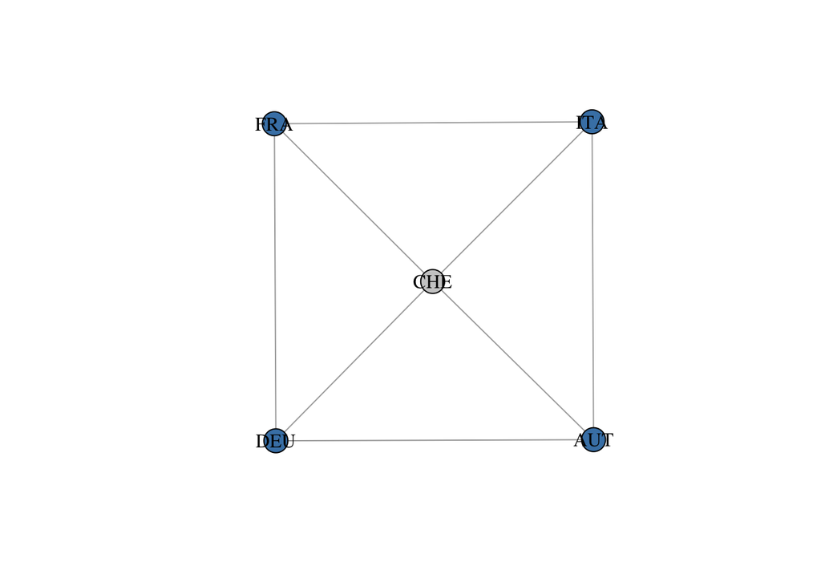

```r
g_borders <- graph_from_data_frame(borders, directed = FALSE, vertices = countries)

plot(
  g_borders,
  vertex.color = ifelse(V(g_borders)$eu_member, "steelblue", "grey80"),
  vertex.label.color = "black"
)
```

**NoteThink first**

Switzerland is the only non-EU country here, yet it borders all four others. What does that tell you about using attributes alone to understand a country’s position in Europe?

## 2. Building blocks

A **network** (or graph) consists of

- **nodes** (vertices): the units, e.g. states, organisations, leaders,
- **edges** (ties, links): the relations between them.

Edges can be

- **undirected** (A–B is the same as B–A: “share a border”) or **directed** (A→B is not B→A: “sends aid to”),
- **binary** (present or absent) or **weighted** (e.g. trade volume).

## 3. Your first network

The simplest way to write down a network is to list who is connected to whom.

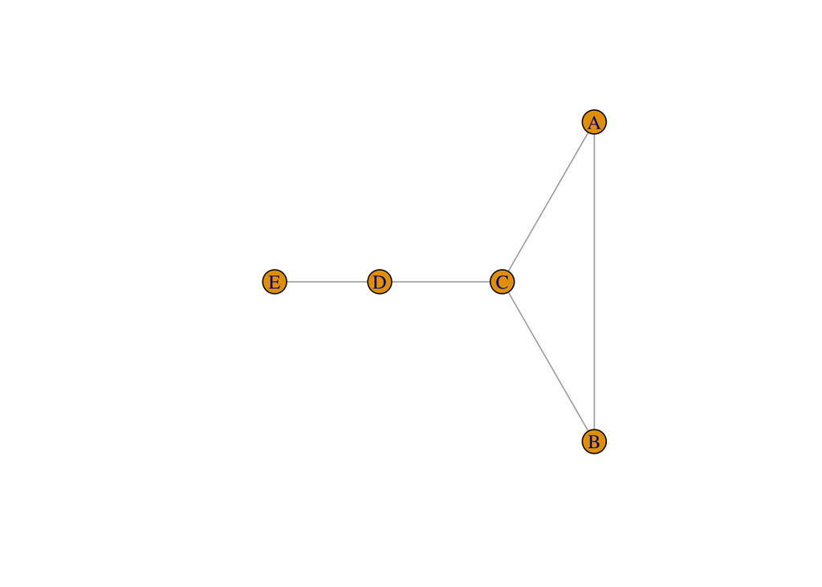

```r
edges <- tribble(
  ~from, ~to,
  "A", "B",
  "A", "C",
  "B", "C",
  "C", "D",
  "D", "E"
)

g <- graph_from_data_frame(edges, directed = FALSE)
plot(g)
```

**NoteThink first**

Before running the next chunk: how many ties does each node have? Which node would you call most “central”, and why?

```r
degree(g)
```

```
A B C D E
2 2 3 2 1
```

Now compare: is the node with the most ties also the one whose removal would split the network?

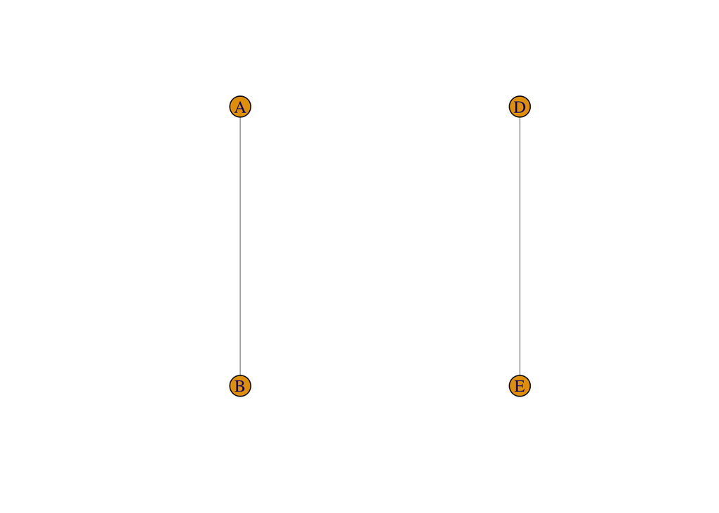

```r
plot(delete_vertices(g, "C"))
```

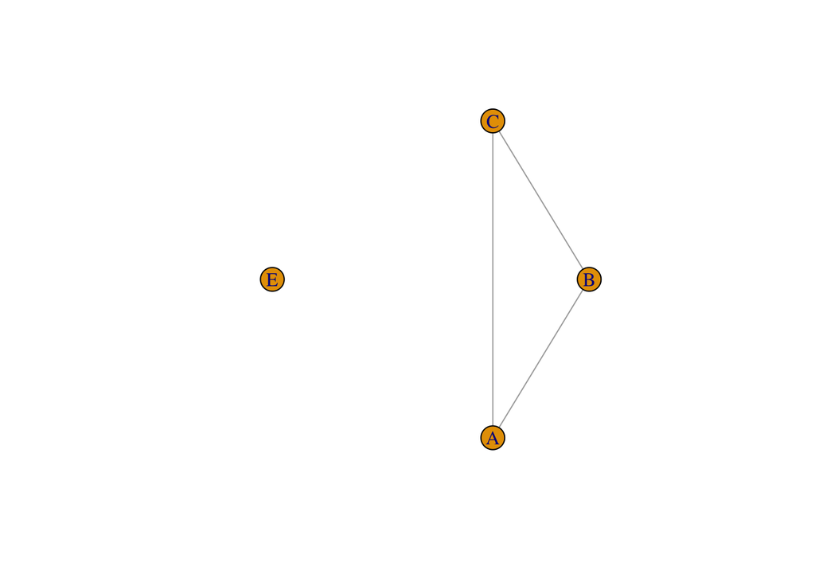

```r
plot(delete_vertices(g, "D"))
```

Already here, “centrality” means more than one thing. We return to this in Session 4.

## 4. Why relations break standard statistics

Regression assumes observations are **independent**. In a network, a tie between A and B is not independent of ties A–C and B–C: if two of your allies are allied with each other, that changes the picture. This **dependence** is not a nuisance in network science; it is the object of study. Sessions 5 and 6 show how to model it.

## Your turn

**TipExercise**

1. Build a directed network of five actors where *one* actor sends ties to everybody and nobody sends ties back. Plot it.
2. Compute `degree(g, mode = "in")` and `degree(g, mode = "out")`. Explain the result in one sentence each.
3. Name one IR phenomenon where direction matters and one where it does not.

```r
# your code here
```